# Выбор локации для скважины

Допустим, вы работаете в добывающей компании «ГлавРосГосНефть». Нужно решить, где бурить новую скважину.

Вам предоставлены пробы нефти в трёх регионах: в каждом 10 000 месторождений, где измерили качество нефти и объём её запасов. Постройте модель машинного обучения, которая поможет определить регион, где добыча принесёт наибольшую прибыль. Проанализируйте возможную прибыль и риски техникой *Bootstrap.*

Шаги для выбора локации:

- В избранном регионе ищут месторождения, для каждого определяют значения признаков;
- Строят модель и оценивают объём запасов;
- Выбирают месторождения с самым высокими оценками значений. Количество месторождений зависит от бюджета компании и стоимости разработки одной скважины;
- Прибыль равна суммарной прибыли отобранных месторождений.

Условия задачи:

- Для обучения модели подходит только линейная регрессия (остальные — недостаточно предсказуемые).
- При разведке региона исследуют 500 точек, из которых с помощью машинного обучения выбирают 200 лучших для разработки.
- Бюджет на разработку скважин в регионе — 10 млрд рублей.
- При нынешних ценах один баррель сырья приносит 450 рублей дохода. Доход с каждой единицы продукта составляет 450 тыс. рублей, поскольку объём указан в тысячах баррелей.
- После оценки рисков нужно оставить лишь те регионы, в которых вероятность убытков меньше 2.5%. Среди них выбирают регион с наибольшей средней прибылью.
- Данные синтетические: детали контрактов и характеристики месторождений не разглашаются.

**Задачи:**

1. Загрузите и подготовьте данные. Поясните порядок действий.
2. Обучите и проверьте модель для каждого региона
3. Подготовьтесь к расчёту прибыли
4. Напишите функцию для расчёта прибыли по выбранным скважинам и предсказаниям модели
5. Посчитайте риски и прибыль для каждого региона
6. Предложите регион для разработки скважин и обоснуйте выбор.

**План:**

1. Загрузите, переработка и анализ данных
   - Загрузка
   - Переработка
   - Исследовательский анализ данных
2. Подготовьте данные для МО
   - `train`, `valid`
   - Масштабирование
3. Обучите и проверьте модель для каждого региона
   - Обучение и проверка модели
     - Обучение и проверка
     - Сохранить результаты
     - Выводы
4. Подготовьтесь к расчёту прибыли
   - Все ключевые значения для расчётов сохраните в отдельных переменных.
   - Рассчитайте достаточный объём сырья для безубыточной разработки новой скважины
   - Выводы
5. Напишите функцию для расчёта прибыли по выбранным скважинам и предсказаниям модели
6. Посчитайте риски и прибыль для каждого региона
   - Bootstrap
   - Найдите среднюю прибыль, 95%-й доверительный интервал и риск убытков
   - Предложите регион для разработки скважин и обоснуйте выбор.

**Содержание**

1. Загрузка, переработка и анализ данных  
   1.1. Загрузка  
   1.2. Подготовка данных  
   1.3. Исследовательский Анализ Данных
2. Подготовка данных для МО  
   2.1. Выборки  
   2.2. Масштабирование  
   2.2.1. Смесь Нормализации и Стандартизации  
   2.2.2. Нормализация  
   2.2.3. Стандартизация  
   2.2.4. Сравнение Распределений
3. Обучение и проверка модели
4. Подготовка к расчёту прибыли
5. Расчёт прибыли
6. Расчёт рисков

```python
import pandas as pd
import numpy as np
import matplotlib.pyplot as plt
import seaborn as sns
import os

from sklearn.preprocessing import MinMaxScaler
from sklearn.preprocessing import StandardScaler
from sklearn.model_selection import train_test_split
from sklearn.linear_model import LinearRegression
from sklearn.metrics import root_mean_squared_error
from sklearn.metrics import mean_absolute_error
```

```python
np.random.seed(12345)
#RANDOM_STATE = 12345
```

## 1. Загрузка, переработка и анализ данных

### 1.1. Загрузка

Данные геологоразведки трёх регионов находятся в файлах.  
id — уникальный идентификатор скважины;  
f0, f1, f2 — три признака точек (неважно, что они означают, но сами признаки значимы);  
product — объём запасов в скважине (тыс. баррелей).

Загрузите и подготовьте данные. Поясните порядок действий.

```python
path_local = 'datasets/'
path_platform = '/datasets/'
path_extra = ''

df_list = [
    'geo_data_0.csv',
    'geo_data_1.csv',
    'geo_data_2.csv'
]

if os.path.exists(path_local) and all(list(map(os.path.exists, map(lambda x: path_local + x, df_list)))):
    df_dir = path_local
    print("Файлы найдены.")
elif os.path.exists(path_platform) and all(list(map(os.path.exists, map(lambda x: path_platform + x, df_list)))):
    df_dir = path_platform
    print("Файлы найдены.")
elif os.path.exists(path_extra) and all(list(map(os.path.exists, map(lambda x: path_extra + x, df_list)))):
    df_dir = path_extra
    print("Файлы найдены.")
elif all(list(map(os.path.exists, df_list))):
    df_dir = ''
    print("Файлы найдены.")
else:
    print("Директория не найдена. Файлы не найдены в текущей.")

geo0 = pd.read_csv(os.path.join(df_dir, 'geo_data_0.csv'), index_col='id')
geo1 = pd.read_csv(os.path.join(df_dir, 'geo_data_1.csv'), index_col='id')
geo2 = pd.read_csv(os.path.join(df_dir, 'geo_data_2.csv'), index_col='id')
```

```
Файлы найдены.
```

```python
geo0.info()
```

```
<class 'pandas.core.frame.DataFrame'>
Index: 100000 entries, txEyH to 1CWhH
Data columns (total 4 columns):
 #   Column   Non-Null Count   Dtype
---  ------   --------------   -----
 0   f0       100000 non-null  float64
 1   f1       100000 non-null  float64
 2   f2       100000 non-null  float64
 3   product  100000 non-null  float64
dtypes: float64(4)
memory usage: 3.8+ MB
```

```python
geo0.sample(5)
```

| id | f0 | f1 | f2 | product |
| --- | --- | --- | --- | --- |
| 7Z2gx | 0.948970 | -0.057547 | 2.095727 | 10.038645 |
| b2HU8 | 0.992974 | 0.206671 | -0.142278 | 114.551489 |
| Y0dXD | 1.199854 | -0.563356 | -1.852991 | 132.603635 |
| Mje59 | 0.691422 | -0.433347 | 0.564974 | 169.072125 |
| yqXxU | 0.420772 | 0.972638 | 0.736190 | 122.325180 |

```python
geo1.info()
```

```
<class 'pandas.core.frame.DataFrame'>
Index: 100000 entries, kBEdx to relB0
Data columns (total 4 columns):
 #   Column   Non-Null Count   Dtype
---  ------   --------------   -----
 0   f0       100000 non-null  float64
 1   f1       100000 non-null  float64
 2   f2       100000 non-null  float64
 3   product  100000 non-null  float64
dtypes: float64(4)
memory usage: 3.8+ MB
```

```python
geo1.sample(5)
```

| id | f0 | f1 | f2 | product |
| --- | --- | --- | --- | --- |
| ElrxD | 8.029940 | 0.142761 | 1.994370 | 53.906522 |
| zgfBu | -6.032070 | -3.118156 | 2.991338 | 84.038886 |
| SkOBP | -6.180053 | -7.242396 | 0.009788 | 3.179103 |
| xNTXq | 19.401135 | -9.446096 | 0.997003 | 26.953261 |
| MBKBZ | -11.330059 | -10.721973 | 4.000191 | 110.992147 |

```python
geo2.info()
```

```
<class 'pandas.core.frame.DataFrame'>
Index: 100000 entries, fwXo0 to V9kWn
Data columns (total 4 columns):
 #   Column   Non-Null Count   Dtype
---  ------   --------------   -----
 0   f0       100000 non-null  float64
 1   f1       100000 non-null  float64
 2   f2       100000 non-null  float64
 3   product  100000 non-null  float64
dtypes: float64(4)
memory usage: 3.8+ MB
```

```python
geo2.sample(5)
```

| id | f0 | f1 | f2 | product |
| --- | --- | --- | --- | --- |
| 27k9G | 0.071381 | 0.053595 | 5.548405 | 52.610856 |
| BXc4A | 1.103934 | 2.408835 | -1.945280 | 52.273440 |
| u56DZ | 0.983287 | 0.338086 | -1.896587 | 71.340473 |
| bITk7 | 3.617945 | 5.317369 | 5.242931 | 162.937918 |
| TEUoB | -2.139805 | 0.276569 | 2.485220 | 155.371552 |

**Выводы:**

Столбец `id` используем в качестве индекса, это позволяет сохранить идентификатор скважин, при этом устранит его влияние на модель, т.к. индекс не учитывается при работе моделей `sklearn`. Среди данных отсутствуют пропуски, все три региона имеют одинаковый формат таблиц, что упростит их параллельную обработку.

### 1.2. Подготовка данных

```python
geo0.duplicated().sum()
```

```
0
```

```python
geo0.index.duplicated().sum()
```

```
10
```

```python
geo1.duplicated().sum()
```

```
0
```

```python
geo1.index.duplicated().sum()
```

```
4
```

```python
geo2.duplicated().sum()
```

```
0
```

```python
geo2.index.duplicated().sum()
```

```
4
```

**Выводы:**

Дубликатов в данных нет, дубликаты в индексах могут создать проблемы при работе с данными, но не повлияют на модели, обработаем в случае надобности.

### 1.3. Исследовательский Анализ Данных

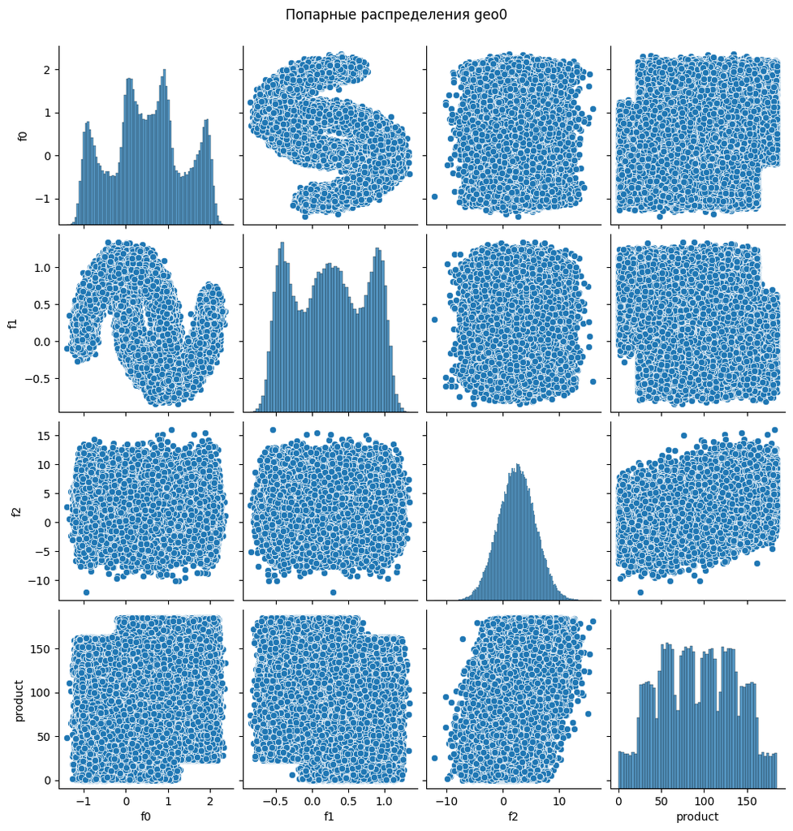

```python
sns.pairplot(geo0)
plt.suptitle("Попарные распределения geo0", y=1.03);
```

```python
geo0.corr()
```

|  | f0 | f1 | f2 | product |
| --- | --- | --- | --- | --- |
| f0 | 1.000000 | -0.440723 | -0.003153 | 0.143536 |
| f1 | -0.440723 | 1.000000 | 0.001724 | -0.192356 |
| f2 | -0.003153 | 0.001724 | 1.000000 | 0.483663 |
| product | 0.143536 | -0.192356 | 0.483663 | 1.000000 |

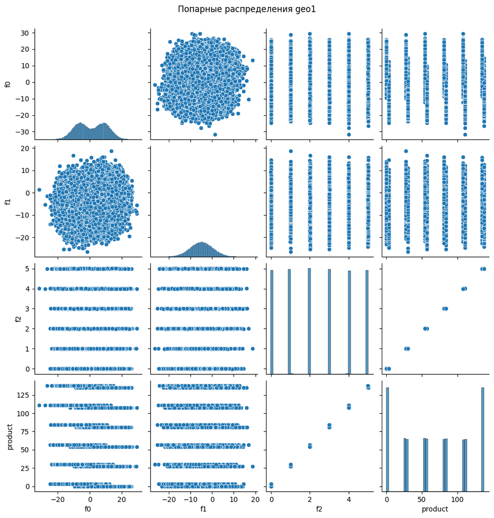

```python
sns.pairplot(geo1)
plt.suptitle("Попарные распределения geo1", y=1.03);
```

```python
geo1.corr()
```

|  | f0 | f1 | f2 | product |
| --- | --- | --- | --- | --- |
| f0 | 1.000000 | 0.182287 | -0.001777 | -0.030491 |
| f1 | 0.182287 | 1.000000 | -0.002595 | -0.010155 |
| f2 | -0.001777 | -0.002595 | 1.000000 | 0.999397 |
| product | -0.030491 | -0.010155 | 0.999397 | 1.000000 |

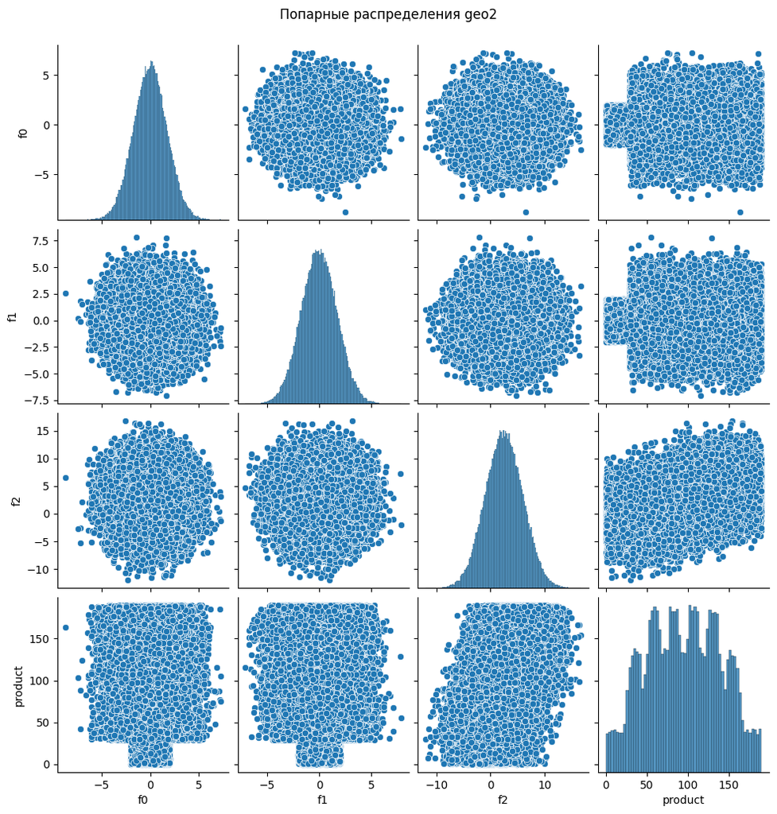

```python
sns.pairplot(geo2)
plt.suptitle("Попарные распределения geo2", y=1.03);
```

```python
geo2.corr()
```

|  | f0 | f1 | f2 | product |
| --- | --- | --- | --- | --- |
| f0 | 1.000000 | 0.000528 | -0.000448 | -0.001987 |
| f1 | 0.000528 | 1.000000 | 0.000779 | -0.001012 |
| f2 | -0.000448 | 0.000779 | 1.000000 | 0.445871 |
| product | -0.001987 | -0.001012 | 0.445871 | 1.000000 |

**Выводы:**

Данные синтетические, природа признаков неизвестна, ИАД проводилось с целью ознакомиться с распределениями, посмотреть зависимости, принять решение о масштабировании и удовлетворить любопытство.

Регион `geo0`:

- f2 распределено нормально. f0, f1 - Несколько вершин (мультимодально). product - несколько вершин, близко к нормальному.
- Имеет значительную отрицательную корреляцию f0, f1, зависимость скорее всего описывается двумя функциями результатами которых являются полумесяцы на графике. Также имеет значительную корреляцию f2, product.

Регион `geo1`:

- f1 распределено нормально. f0 - две вершины. f2, product - дискретные, близкие к друг другу.
- Особенности распределения f2, product, приводят к тому что мы имеем абсурдную, практически 1 к 1 корреляцию данных признаков.

Регион `geo2`:

- f1, f2, f3 распределены нормально. product - мультимодально, близко к нормальному.
- Имеет значительную корреляцию f2, product.

В целом во всех регионах можем наблюдать корреляцию f2, product. Не все признаки распределены нормально, проведём масштабирование несколькими методами чтобы сравнить результаты.

## 2. Подготовка данных для МО

### 2.1. Выборки

2.1. Разбейте данные на обучающую и валидационную выборки в соотношении 75:25.

```python
feat0 = geo0.drop('product', axis=1)
feat1 = geo1.drop('product', axis=1)
feat2 = geo2.drop('product', axis=1)

targ0 = geo0['product']
targ1 = geo1['product']
targ2 = geo2['product']
```

```python
feat0_train, feat0_val, targ0_train, targ0_val = train_test_split(feat0, targ0)
feat1_train, feat1_val, targ1_train, targ1_val = train_test_split(feat1, targ1)
feat2_train, feat2_val, targ2_train, targ2_val = train_test_split(feat2, targ2)
```

```python
sample_names = 'feat0_train, feat0_val, targ0_train, targ0_val, feat1_train, feat1_val, \
targ1_train, targ1_val, feat2_train, feat2_val, targ2_train, targ2_val'
sample_names = sample_names.split(', ')
for name, sample in zip(sample_names, [feat0_train, feat0_val, targ0_train, targ0_val, feat1_train, feat1_val,
               targ1_train, targ1_val, feat2_train, feat2_val, targ2_train, targ2_val]):
    print(name, 'это выборка размером', len(sample))
```

```
feat0_train это выборка размером 75000
feat0_val это выборка размером 25000
targ0_train это выборка размером 75000
targ0_val это выборка размером 25000
feat1_train это выборка размером 75000
feat1_val это выборка размером 25000
targ1_train это выборка размером 75000
targ1_val это выборка размером 25000
feat2_train это выборка размером 75000
feat2_val это выборка размером 25000
targ2_train это выборка размером 75000
targ2_val это выборка размером 25000
```

### 2.2. Масштабирование

```python
scaler = StandardScaler()
normalizer = MinMaxScaler()
```

#### 2.2.1. Смесь Нормализации и Стандартизации

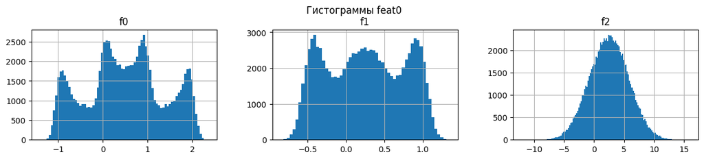

```python
fig, axis = plt.subplots(1, 3, figsize=(15,2.5))
plt.suptitle('Гистограммы feat0', y=1.05)
feat0.hist(ax=axis, bins='auto');
```

```python
feat0_train_transd = feat0_train.copy()
feat0_val_transd = feat0_val.copy()

normalizer.fit(feat0_train[['f0','f1']])
scaler.fit(feat0_train['f2'].to_frame())
feat0_train_transd[['f0','f1']] = normalizer.transform(feat0_train[['f0','f1']])  #transformed
feat0_train_transd['f2'] = scaler.transform(feat0_train['f2'].to_frame())
feat0_val_transd[['f0','f1']] = normalizer.transform(feat0_val[['f0','f1']])  #transformed
feat0_val_transd['f2'] = scaler.transform(feat0_val['f2'].to_frame())
```

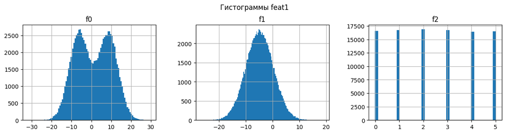

```python
fig, axis = plt.subplots(1, 3, figsize=(15,3))
plt.suptitle('Гистограммы feat1', y=1.05)
feat1.hist(ax=axis, bins='auto');
```

```python
feat1_train_transd = feat1_train.copy()
feat1_val_transd = feat1_val.copy()

normalizer.fit(feat1_train[['f0','f2']])
scaler.fit(feat1_train['f1'].to_frame())
feat1_train_transd[['f0','f2']] = normalizer.transform(feat1_train[['f0','f2']])  #transformed
feat1_train_transd['f1'] = scaler.transform(feat1_train['f1'].to_frame())
feat1_val_transd[['f0','f2']] = normalizer.transform(feat1_val[['f0','f2']])  #transformed
feat1_val_transd['f1'] = scaler.transform(feat1_val['f1'].to_frame())
```

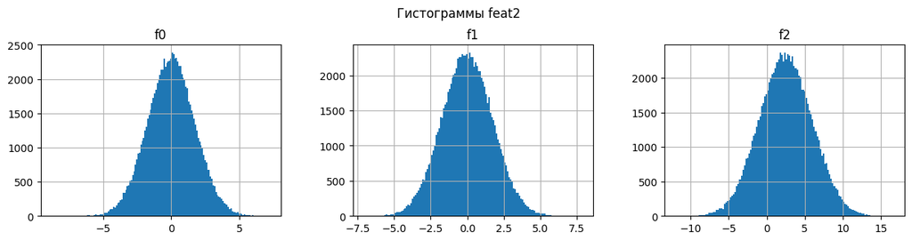

```python
fig, axis = plt.subplots(1, 3, figsize=(15,3))
plt.suptitle('Гистограммы feat2', y=1.05)
feat2.hist(ax=axis, bins='auto');
```

```python
scaler.fit(feat2_train)
feat2_train_transd = scaler.transform(feat2_train)
feat2_val_transd = scaler.transform(feat2_train)
```

#### 2.2.2. Нормализация

```python
normalizer.fit(feat0_train)
feat0_train_normd = normalizer.transform(feat0_train)
feat0_val_normd = normalizer.transform(feat0_val)

normalizer.fit(feat1_train)
feat1_train_normd = normalizer.transform(feat1_train)
feat1_val_normd = normalizer.transform(feat1_val)

normalizer.fit(feat2_train)
feat2_train_normd = normalizer.transform(feat2_train)
feat2_val_normd = normalizer.transform(feat2_val)
```

#### 2.2.3. Стандартизация

```python
scaler = StandardScaler()
```

```python
scaler.fit(feat0_train)
feat0_train_scaled = scaler.transform(feat0_train)
feat0_val_scaled = scaler.transform(feat0_val)

scaler.fit(feat1_train)
feat1_train_scaled = scaler.transform(feat1_train)
feat1_val_scaled = scaler.transform(feat1_val)

scaler.fit(feat2_train)
feat2_train_scaled = scaler.transform(feat2_train)
feat2_val_scaled = scaler.transform(feat2_val)
```

#### 2.2.4. Сравнение Распределений

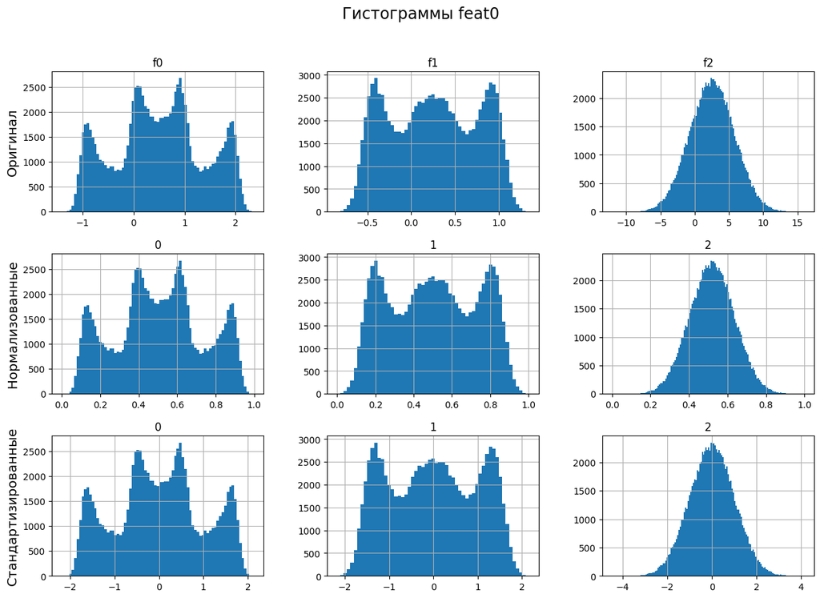

```python
fig, axs = plt.subplots(3, 3, figsize=(15, 10))
plt.suptitle('Гистограммы feat0', size='xx-large')
pd.DataFrame(feat0).hist(ax=axs[0], bins='auto');
pd.DataFrame(feat0_train_normd).append(pd.DataFrame(feat0_val_normd)).hist(ax=axs[1], bins='auto');
pd.DataFrame(feat0_train_scaled).append(pd.DataFrame(feat0_val_scaled)).hist(ax=axs[2], bins='auto');
axs[0, 0].set_ylabel('Оригинал', size='x-large')
axs[1, 0].set_ylabel('Нормализованные', size='x-large')
axs[2, 0].set_ylabel('Стандартизированные', size='x-large');
```

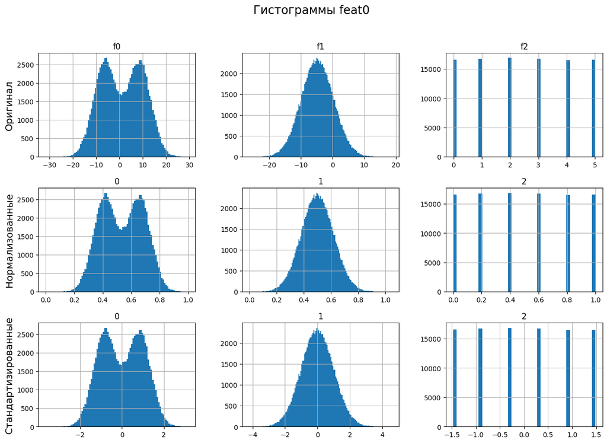

```python
fig, axs = plt.subplots(3, 3, figsize=(15, 10))
plt.suptitle('Гистограммы feat0', size='xx-large')
pd.DataFrame(feat1).hist(ax=axs[0], bins='auto');
pd.DataFrame(feat1_train_normd).append(pd.DataFrame(feat1_val_normd)).hist(ax=axs[1], bins='auto');
pd.DataFrame(feat1_train_scaled).append(pd.DataFrame(feat1_val_scaled)).hist(ax=axs[2], bins='auto');
axs[0, 0].set_ylabel('Оригинал', size='x-large')
axs[1, 0].set_ylabel('Нормализованные', size='x-large')
axs[2, 0].set_ylabel('Стандартизированные', size='x-large');
#axs[1,1].remove()
```

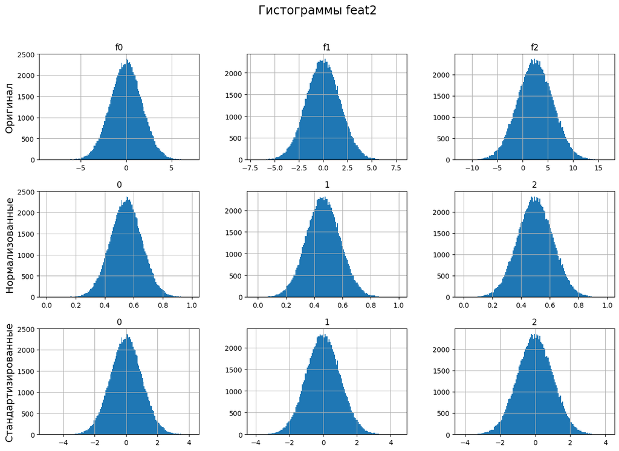

```python
fig, axs = plt.subplots(3, 3, figsize=(15, 10))
plt.suptitle('Гистограммы feat2', size='xx-large')
pd.DataFrame(feat2).hist(ax=axs[0], bins='auto');
pd.DataFrame(feat2_train_normd).append(pd.DataFrame(feat2_val_normd)).hist(ax=axs[1], bins='auto');
pd.DataFrame(feat2_train_scaled).append(pd.DataFrame(feat2_val_scaled)).hist(ax=axs[2], bins='auto');
axs[0, 0].set_ylabel('Оригинал', size='x-large')
axs[1, 0].set_ylabel('Нормализованные', size='x-large')
axs[2, 0].set_ylabel('Стандартизированные', size='x-large');
```

**Выводы:**

В связи с ненормальным распределением ряда признаков, для масштабирования используем три подхода, чтобы сравнить какой из них лучше скажется на модели. В первом случае используем стандартизацию для признаков распределённых нормально, нормализацию для остальных. Учитывая что все в `geo2` распределены нормально, его пропускаем.

Во втором случае используем нормализацию для всех. В третьем - стандартизацию для всех.

После этого мы можем сравнить получившиеся распределения. Можно наблюдать что по форме и высоте они практически совпадают, хоть и отличаются по границам и ширине.

Использование нескольких способов позволит нам оценить их влияние на качество модели и применить оптимальный.

## 3. Обучение и проверка модели

Обучите и проверьте модель для каждого региона:  
2.2. Обучите модель и сделайте предсказания на валидационной выборке.  
2.3. Сохраните предсказания и правильные ответы на валидационной выборке.  
2.4. Напечатайте на экране средний запас предсказанного сырья и RMSE модели.  
2.5. Проанализируйте результаты.

Для обучения модели подходит только линейная регрессия (остальные — недостаточно предсказуемые).

```python
model = LinearRegression()
```

```python
def regress(feat_train, feat_val, targ_train, targ_val):
    model.fit(feat_train, targ_train)
    pred = model.predict(feat_val)
    r2 = model.score(feat_val, targ_val)
    rmse = root_mean_squared_error(targ_val, pred)
    mae = mean_absolute_error(targ_val, pred)
    mean_product = pred.mean()
    return pred, [r2, rmse, mae, mean_product, targ_val.mean()]
```

```python
geo_list = ('geo0_basel', 'geo0_transd', 'geo0_normd', 'geo0_scaled', # basel - baseline
            'geo1_basel', 'geo1_transd', 'geo1_normd', 'geo1_scaled',
            'geo2_basel', 'geo2_normd', 'geo2_scaled')
samples_list = [
    [feat0_train, feat0_val, targ0_train, targ0_val],
    [feat0_train_transd, feat0_val_transd, targ0_train, targ0_val],
    [feat0_train_normd, feat0_val_normd, targ0_train, targ0_val],
    [feat0_train_scaled, feat0_val_scaled, targ0_train, targ0_val],
    [feat1_train, feat1_val, targ1_train, targ1_val],
    [feat1_train_transd, feat1_val_transd, targ1_train, targ1_val],
    [feat1_train_normd, feat1_val_normd, targ1_train, targ1_val],
    [feat1_train_scaled, feat1_val_scaled, targ1_train, targ1_val],
    [feat2_train, feat2_val, targ2_train, targ2_val],
    [feat2_train_normd, feat2_val_normd, targ2_train, targ2_val],
    [feat2_train_scaled, feat2_val_scaled, targ2_train, targ2_val]
]

geo_preds = pd.DataFrame(columns=geo_list)
geo_evals = pd.DataFrame(index=geo_list, columns=['r2', 'rmse', 'mae', 'mean_pred', 'mean_true'])

for samples, name in zip(samples_list, geo_list):
    geo_preds[name], geo_evals.loc[name] = regress(*samples)
```

```python
geo_evals
```

|  | r2 | rmse | mae | mean_pred | mean_true |
| --- | --- | --- | --- | --- | --- |
| geo0_basel | 0.275063 | 37.579515 | 30.974592 | 92.663866 | 92.627343 |
| geo0_transd | 0.275063 | 37.579515 | 30.974592 | 92.663866 | 92.627343 |
| geo0_normd | 0.275063 | 37.579515 | 30.974592 | 92.663866 | 92.627343 |
| geo0_scaled | 0.275063 | 37.579515 | 30.974592 | 92.663866 | 92.627343 |
| geo1_basel | 0.999625 | 0.890416 | 0.71845 | 69.223452 | 69.226424 |
| geo1_transd | 0.999625 | 0.890416 | 0.71845 | 69.223452 | 69.226424 |
| geo1_normd | 0.999625 | 0.890416 | 0.71845 | 69.223452 | 69.226424 |
| geo1_scaled | 0.999625 | 0.890416 | 0.71845 | 69.223452 | 69.226424 |
| geo2_basel | 0.201905 | 40.029386 | 32.856814 | 95.049536 | 95.114448 |
| geo2_normd | 0.201905 | 40.029386 | 32.856814 | 95.049536 | 95.114448 |
| geo2_scaled | 0.201905 | 40.029386 | 32.856814 | 95.049536 | 95.114448 |

```python
geo_evals[~geo_evals.astype(float).round(10).duplicated()]
```

|  | r2 | rmse | mae | mean_pred | mean_true |
| --- | --- | --- | --- | --- | --- |
| geo0_basel | 0.275063 | 37.579515 | 30.974592 | 92.663866 | 92.627343 |
| geo1_basel | 0.999625 | 0.890416 | 0.71845 | 69.223452 | 69.226424 |
| geo2_basel | 0.201905 | 40.029386 | 32.856814 | 95.049536 | 95.114448 |

**Выводы:**

Ни стандартизация, ни нормирование не повлияли на итоговою модель, в дальнейшем будем использовать результаты моделей построенных на оригинальных данных.

Оценка результатов работы моделей записана в таблицу `geo_evals`. Предсказания в таблицу `geo_preds`. Истинные значения целевого параметра уже сохранены в переменных во время разбиения на выборки, повторно не сохраняем.

`geo_evals` позволяет выведена на экран, оценить r2, rmse, mae, средние значение предсказаний и среднее значение истинных значений для каждого региона с разными способами масштабирования.

Модели `geo1` имеет предсказуемо абсурдный r2, связанный с абсурдной корреляцией f2, product. Модели `geo0`, `geo2`, имеют r2 равный 0.275 и 0.2 соответственно, это, в целом, довольно низкие значения, однако, не зная стандартов индустрии невозможно говорить о низком качестве с уверенностью.

Среднее значение предсказаний для регионов, соответственно, 92,66, 69,22 и 95,04. Регион `geo_1` имеет практически нулевую ошибку, и таким образом наиболее надёжен, однако исходя из среднего, он наименее привлекателен с точки зрения доступного количества сырья. Регионы `geo_0`, `geo_2` имеют среднюю абсолютную ошибку около 1/3 от значений, и тем самым достаточно ненадёжны, однако имеют на ~34% больше сырья, что может сделать ошибку незначительным фактором. Из них `geo2` имеет чуть более высокие оценки средних запасов сырья.

В целом требуется дальнейшая оценка, с учётом условий заказчика, перед выбором региона.

## 4. Подготовка к расчёту прибыли

Подготовьтесь к расчёту прибыли:  
3.1. Все ключевые значения для расчётов сохраните в отдельных переменных.  
3.2. Рассчитайте достаточный объём сырья для безубыточной разработки новой скважины. Сравните полученный объём сырья со средним запасом в каждом регионе.  
3.3. Напишите выводы по этапу подготовки расчёта прибыли.

```python
                          # Все ключевые значения для расчётов сохраните в отдельных переменных.
# n_regions = 3           # Вам предоставлены пробы нефти в трёх регионах                                     # Не используется
# n_wells = 10000         # в каждом 10 000 месторождений, где измерили качество нефти и объём её запасов     # Не используется
N_TO_EXPLORE = 500        # При разведке региона исследуют 500 точек
N_TO_DEVELOP = 200        # Из которых с помощью машинного обучения выбирают 200 лучших для разработки.
EXPENSES = 10 * 10**9     # Бюджет на разработку скважин в регионе — 10 млрд рублей.
#per_barrel = 450         # При нынешних ценах один баррель сырья приносит 450 рублей дохода.                 # Не используется
PER_PRODUCT = 450 * 10**3 # Доход с каждой единицы продукта составляет 450 тыс. рублей,
                          # поскольку объём указан в тысячах баррелей.
BOOTSTRAP_SAMPLES = 1000  # Примените технику Bootstrap с 1000 выборок, чтобы найти распределение прибыли.
LOSS_PROB_MAX = 0.025     # После оценки рисков нужно оставить лишь те регионы, в которых вероятность убытков меньше 2.5%.
                          # Среди них выбирают регион с наибольшей средней прибылью.
```

```python
product_viable = EXPENSES/PER_PRODUCT/N_TO_DEVELOP
product_viable
```

```
111.11111111111111
```

```python
111.11111111111111/95.114448
```

```
1.1681833143910074
```

**Выводы:**

Соответствующий нуждам задачи условия заказчика сохранены в переменные. в данном случае под бюджетом подразумеваются инвестиции, т.е. затраты на разработку региона, параметр сохранён в `EXPENSES`.

Оценивая прибыльность, можно сказать, что для того чтобы окупиться среднее значение сырья в разрабатываемых скважинах должно быть 111.(1), что значительно ~(17%) выше самого высокого среднего значения среди регионов.

Таким образом для извлечения прибыли необходимо выбрать скважины и регион, таким образом, чтобы получить значение сырья выше среднего, достаточное для оправдания инвестиций.

## 5. Расчёт прибыли

Напишите функцию для расчёта прибыли по выбранным скважинам и предсказаниям модели:  
4.1. Выберите скважины с максимальными значениями предсказаний.  
4.2. Просуммируйте целевое значение объёма сырья, соответствующее этим предсказаниям.  
4.3. Рассчитайте прибыль для полученного объёма сырья.

```python
geo_preds
```

|  | geo0_basel | geo0_transd | geo0_normd | geo0_scaled | geo1_basel | geo1_transd | geo1_normd | geo1_scaled | geo2_basel | geo2_normd | geo2_scaled |
| --- | --- | --- | --- | --- | --- | --- | --- | --- | --- | --- | --- |
| 0 | 112.958982 | 112.958982 | 112.958982 | 112.958982 | 29.117188 | 29.117188 | 29.117188 | 29.117188 | 78.982209 | 78.982209 | 78.982209 |
| 1 | 68.877696 | 68.877696 | 68.877696 | 68.877696 | 81.337208 | 81.337208 | 81.337208 | 81.337208 | 81.886679 | 81.886679 | 81.886679 |
| 2 | 127.801985 | 127.801985 | 127.801985 | 127.801985 | 83.587069 | 83.587069 | 83.587069 | 83.587069 | 73.981274 | 73.981274 | 73.981274 |
| 3 | 142.532485 | 142.532485 | 142.532485 | 142.532485 | 111.283568 | 111.283568 | 111.283568 | 111.283568 | 120.919108 | 120.919108 | 120.919108 |
| 4 | 105.733497 | 105.733497 | 105.733497 | 105.733497 | 111.627559 | 111.627559 | 111.627559 | 111.627559 | 67.622778 | 67.622778 | 67.622778 |
| ... | ... | ... | ... | ... | ... | ... | ... | ... | ... | ... | ... |
| 24995 | 61.956631 | 61.956631 | 61.956631 | 61.956631 | 55.872151 | 55.872151 | 55.872151 | 55.872151 | 97.545332 | 97.545332 | 97.545332 |
| 24996 | 109.882884 | 109.882884 | 109.882884 | 109.882884 | 81.691397 | 81.691397 | 81.691397 | 81.691397 | 113.845259 | 113.845259 | 113.845259 |
| 24997 | 110.876772 | 110.876772 | 110.876772 | 110.876772 | 81.608170 | 81.608170 | 81.608170 | 81.608170 | 120.308259 | 120.308259 | 120.308259 |
| 24998 | 57.693018 | 57.693018 | 57.693018 | 57.693018 | 135.144257 | 135.144257 | 135.144257 | 135.144257 | 55.882968 | 55.882968 | 55.882968 |
| 24999 | 85.462470 | 85.462470 | 85.462470 | 85.462470 | 3.541762 | 3.541762 | 3.541762 | 3.541762 | 99.355010 | 99.355010 | 99.355010 |

25000 rows × 11 columns

```python
def profit_question_mark(pred, true_val):
    best_pred_wells = pred.sort_values(ascending=False).head(N_TO_DEVELOP)
    best_true_wells = true_val.iloc[best_pred_wells.index]
    product_sum = best_true_wells.sum()
    profit = product_sum * PER_PRODUCT - EXPENSES
    return profit
```

```python
for i, true_val in zip([0, 4, 8], [targ0_val, targ1_val, targ2_val]):
    print(f'Истинная прибыль {N_TO_DEVELOP} лучших скважин из проверочной выборки в регионе "geo{round(i/4)}",',
          round(profit_question_mark(geo_preds.iloc[:, i], true_val) / (10**9), 3), "миллиардов рублей")
```

```
Истинная прибыль 200 лучших скважин из проверочной выборки в регионе "geo0", 3.333 миллиардов рублей
Истинная прибыль 200 лучших скважин из проверочной выборки в регионе "geo1", 2.415 миллиардов рублей
Истинная прибыль 200 лучших скважин из проверочной выборки в регионе "geo2", 2.697 миллиардов рублей
```

**Выводы:**

Создана функция расчёта прибыли на основе лучших скважин выборки, в соответствии с условиями заказчика.

Применение к проверочным выборкам показывает что `geo0` регион является лидером с этой точки зрения. однако ненадёжность модели делает данные результаты мало значимыми. Впрочем если возможно значительно улучшить качество модели, например используя другую модель, возможно регион `geo0` станет наиболее привлекательным.

## 6. Расчёт рисков

Посчитайте риски и прибыль для каждого региона:  
5.1. Примените технику Bootstrap с 1000 выборок, чтобы найти распределение прибыли.  
5.2. Найдите среднюю прибыль, 95%-й доверительный интервал и риск убытков. Убыток — это отрицательная прибыль.  
5.3. Напишите выводы: предложите регион для разработки скважин и обоснуйте выбор.

```python
def millions(num) :
    return round(num/10**6, 3)

def bootstrap_oil(prediction, true_val):

    bs_profit = []

    for i in range(BOOTSTRAP_SAMPLES):
        sub_sample = prediction.sample(N_TO_EXPLORE, replace=True) # random.seed() instead of random_state=
        bs_profit.append(profit_question_mark(sub_sample, true_val))

    bs_profit = pd.Series(bs_profit)
    risk = (bs_profit < 0).sum()/bs_profit.size

    return millions(bs_profit.mean()), (millions(bs_profit.quantile(0.025)), millions(bs_profit.quantile(0.975))), \
           risk*100, risk <  LOSS_PROB_MAX
```

```python
geo_bs_profit = pd.DataFrame(columns=['Бутстрап Среднее, млн', '95% доверительный интервал, млн',
                                      'Риск Убытков, %', 'Приемлимый Риск'])
geo_bs_profit.index.name = 'Регион'

for i, true_val in zip([0, 4, 8], [targ0_val, targ1_val, targ2_val]):
    geo_bs_profit.loc[f'geo{round(i/4)}'] = bootstrap_oil(geo_preds.iloc[:, i], true_val)
```

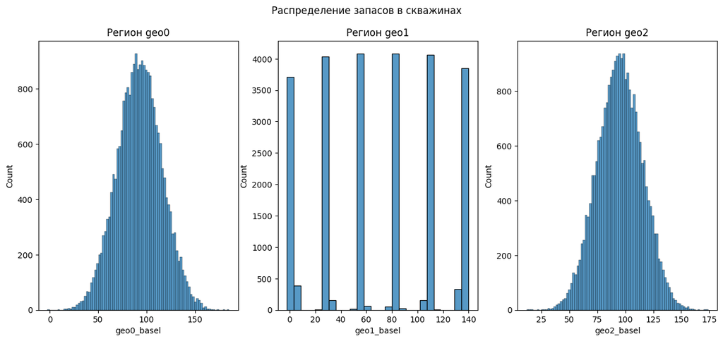

```python
f, axs = plt.subplots(1, 3, figsize=(15, 6))
plt.suptitle('Распределение запасов в скважинах')

for i in range(3):
    sns.histplot(geo_preds.iloc[:, i*4], ax=axs[i])
    axs[i].set_title(f'Регион geo{i}')
```

```python
geo_bs_profit
```

| Регион | Бутстрап Среднее, млн | 95% доверительный интервал, млн | Риск Убытков, % | Приемлимый Риск |
| --- | --- | --- | --- | --- |
| geo0 | 401.649 | (-89.486, 887.517) | 6.4 | False |
| geo1 | 484.450 | (108.824, 891.841) | 0.4 | True |
| geo2 | 401.135 | (-140.966, 924.333) | 6.8 | False |

**Выводы:**

Произведена оценка прибыльности бутстарпом с учётом условий задачи.

Из трёх регионов имеет приемлемый для заказчика риск убытков (<2.5%) только `geo1`, таким образом, с точки зрения условий заказчика, подходит только он. К счастью это также наиболее прибыльный регион.

Примечательно что это регион с наименьшим средним значением предсказанного количества запасов в скважинах. На графике можно увидеть, что это скорее всего связано с тем что в результате не равномерного, дискретного, распределения запасов в скважинах наиболее прибыльные скважины более значительно отличаются от скважин в среднем. Это позволяет получить более высокую прибыль, ввиду метода выбора разработки скважин в регионе, используемого заказчиком.